# Practical Machine Learning Course Project

Kathryn Christensen

Saturday, May 23, 2015

## Introduction:

This project will use data from accelerometers on the belt, forearm, arm, and dumbell of 6 participants who were then asked to perform barbell lifts correctly and incorrectly in 5 different ways. The goal of the project is to predict the manner in which they did the exercise. This is the “classe” variable in the training set.

## Data:

The data was collected as part of the Human Activity Recognition Project. http://groupware.les.inf.puc-rio.br/har provides more information on the collection and project.

```r
train<-read.csv("pml-training.csv")
test<-read.csv("pml-testing2.csv")
```

First look at the data:

```r
summary (train)
```

```
##        X            user_name    raw_timestamp_part_1 raw_timestamp_part_2
##  Min.   :    1   adelmo  :3892   Min.   :1.322e+09    Min.   :   294
##  1st Qu.: 4906   carlitos:3112   1st Qu.:1.323e+09    1st Qu.:252912
##  Median : 9812   charles :3536   Median :1.323e+09    Median :496380
##  Mean   : 9812   eurico  :3070   Mean   :1.323e+09    Mean   :500656
##  3rd Qu.:14717   jeremy  :3402   3rd Qu.:1.323e+09    3rd Qu.:751891
##  Max.   :19622   pedro   :2610   Max.   :1.323e+09    Max.   :998801
##
##           cvtd_timestamp  new_window    num_window      roll_belt
##  28/11/2011 14:14: 1498   no :19216   Min.   :  1.0   Min.   :-28.90
##  05/12/2011 11:24: 1497   yes:  406   1st Qu.:222.0   1st Qu.:  1.10
##  30/11/2011 17:11: 1440               Median :424.0   Median :113.00
##  05/12/2011 11:25: 1425               Mean   :430.6   Mean   : 64.41
##  02/12/2011 14:57: 1380               3rd Qu.:644.0   3rd Qu.:123.00
##  02/12/2011 13:34: 1375               Max.   :864.0   Max.   :162.00
##  (Other)         :11007
##    pitch_belt          yaw_belt       total_accel_belt kurtosis_roll_belt
##  Min.   :-55.8000   Min.   :-180.00   Min.   : 0.00             :19216
##  1st Qu.:  1.7600   1st Qu.: -88.30   1st Qu.: 3.00    #DIV/0!  :   10
##  Median :  5.2800   Median : -13.00   Median :17.00    -1.908453:    2
##  Mean   :  0.3053   Mean   : -11.21   Mean   :11.31    -0.016850:    1
##  3rd Qu.: 14.9000   3rd Qu.:  12.90   3rd Qu.:18.00    -0.021024:    1
##  Max.   : 60.3000   Max.   : 179.00   Max.   :29.00    -0.025513:    1
##                                                        (Other)  :  391
##  kurtosis_picth_belt kurtosis_yaw_belt skewness_roll_belt
##           :19216            :19216              :19216
##  #DIV/0!  :   32     #DIV/0!:  406     #DIV/0!  :    9
##  47.000000:    4                       0.000000 :    4
##  -0.150950:    3                       0.422463 :    2
##  -0.684748:    3                       -0.003095:    1
##  -1.750749:    3                       -0.010002:    1
##  (Other)  :  361                       (Other)  :  389
##  skewness_roll_belt.1 skewness_yaw_belt max_roll_belt     max_picth_belt
##           :19216             :19216     Min.   :-94.300   Min.   : 3.00
##  #DIV/0!  :   32      #DIV/0!:  406     1st Qu.:-88.000   1st Qu.: 5.00
##  0.000000 :    4                        Median : -5.100   Median :18.00
##  -2.156553:    3                        Mean   : -6.667   Mean   :12.92
##  -3.072669:    3                        3rd Qu.: 18.500   3rd Qu.:19.00
##  -6.324555:    3                        Max.   :180.000   Max.   :30.00
##  (Other)  :  361                        NA's   :19216     NA's   :19216
```

[output cut: 313 more lines]

```
##  Min.   :-446.00   Min.   :-1280.0   Min.   :-896.0   Min.   :-973.0
##  1st Qu.:-182.00   1st Qu.: -616.0   1st Qu.:   2.0   1st Qu.: 191.0
##  Median : -39.00   Median : -378.0   Median : 591.0   Median : 511.0
##  Mean   : -55.29   Mean   : -312.6   Mean   : 380.1   Mean   : 393.6
##  3rd Qu.:  26.00   3rd Qu.:  -73.0   3rd Qu.: 737.0   3rd Qu.: 653.0
##  Max.   : 291.00   Max.   :  672.0   Max.   :1480.0   Max.   :1090.0
##
##  classe
##  A:5580
##  B:3797
##  C:3422
##  D:3216
##  E:3607
##
##
```

The data has many variables that are very sparsley populated. These can be removed without impacting the analysis. If any particular column has more than 10% of either NAs or blanks, the column is removed.

```r
cutoff<-.1*nrow(train)
keep<-rep_len(1, ncol(train))
for(i in 1:(length(names(train))-1)){
        if ((sum(is.na(train[[i]]))>cutoff)|| (sum(train[[i]]=="")>cutoff)) {
                keep[i]<-0
        }
}
train<-subset(train,select=subset(names(train),keep==1))
```

The first 7 columns of data are informational and will not contribute to the analysis. These are removed as well.

```r
train<-train[,8:60]
```

Looking at the summary statistics it appears there are some outliers in the gyro measurements for forearm and barbell.

```r
sdDB<-apply(train[,31:33],2,sd)
olNum<-which (train$gyros_dumbbell_x < -(as.numeric(3*sdDB[1])))
```

Row number 5373 appears to be the only row that has an extreme value (>3 SD from mean) in the gyros_dumbbell_x variable. Let’s look at the other gyro values in that row for dumbbell and forearm:

```r
rbind(colMeans(train[,31:33]),train[olNum,31:33])
```

```
##      gyros_dumbbell_x gyros_dumbbell_y gyros_dumbbell_z
## 1           0.1610845       0.04605647       -0.1289889
## 5373     -204.0000000      52.00000000      317.0000000
```

```r
rbind(colMeans(train[,44:46]),train[olNum,44:46])
```

```
##      gyros_forearm_x gyros_forearm_y gyros_forearm_z
## 1          0.1579513       0.0751748        0.151245
## 5373     -22.0000000     311.0000000      231.000000
```

Impute those values with the mean for others in that class:

```r
train[olNum,"gyros_dumbbell_x"]<-NA
train[olNum,"gyros_dumbbell_y"]<-NA
train[olNum,"gyros_dumbbell_z"]<-NA
train[olNum,"gyros_forearm_x"]<-NA
train[olNum,"gyros_forearm_y"]<-NA
train[olNum,"gyros_forearm_z"]<-NA

train[olNum,"gyros_dumbbell_x"]<-mean(train[train$classe==train$classe[olNum],"gyros_dumbbell_x"],na.rm=TRUE)
train[olNum,"gyros_dumbbell_y"]<-mean(train[train$classe==train$classe[olNum],"gyros_dumbbell_y"],na.rm=TRUE)
train[olNum,"gyros_dumbbell_z"]<-mean(train[train$classe==train$classe[olNum],"gyros_dumbbell_z"],na.rm=TRUE)

train[olNum,"gyros_forearm_x"]<-mean(train[train$classe==train$classe[olNum],"gyros_forearm_x"],na.rm=TRUE)
train[olNum,"gyros_forearm_y"]<-mean(train[train$classe==train$classe[olNum],"gyros_forearm_y"],na.rm=TRUE)
train[olNum,"gyros_forearm_z"]<-mean(train[train$classe==train$classe[olNum],"gyros_forearm_z"],na.rm=TRUE)
```

Much better now:

```r
summary(cbind(train[,31:33],train[,44:46]))
```

```
##  gyros_dumbbell_x  gyros_dumbbell_y   gyros_dumbbell_z  gyros_forearm_x
##  Min.   :-1.9900   Min.   :-2.10000   Min.   :-2.3800   Min.   :-4.9500
##  1st Qu.:-0.0300   1st Qu.:-0.14000   1st Qu.:-0.3100   1st Qu.:-0.2200
##  Median : 0.1300   Median : 0.03000   Median :-0.1300   Median : 0.0500
##  Mean   : 0.1715   Mean   : 0.04341   Mean   :-0.1452   Mean   : 0.1591
##  3rd Qu.: 0.3500   3rd Qu.: 0.21000   3rd Qu.: 0.0300   3rd Qu.: 0.5600
##  Max.   : 2.2200   Max.   : 4.37000   Max.   : 1.8700   Max.   : 3.9700
##  gyros_forearm_y    gyros_forearm_z
##  Min.   :-7.02000   Min.   :-8.0900
##  1st Qu.:-1.46000   1st Qu.:-0.1800
##  Median : 0.03000   Median : 0.0800
##  Mean   : 0.05933   Mean   : 0.1395
##  3rd Qu.: 1.62000   3rd Qu.: 0.4900
##  Max.   : 6.13000   Max.   : 4.3100
```

## Exploratory Data Analysis

For the exploratory data analysis I wanted to be able to view the data across the different classes (“classe” variable). I starting by centering and scaling the data to make it easier to view.

```r
tr<-train[,-53]
preProcValues <- preProcess(tr, method = c("center", "scale"))
tr<-predict(preProcValues,tr)

tr<-cbind(tr,train[,53])

colnames(tr)[53]<-"classe"
belt<-cbind(tr[,1:13],tr[,53])
colnames(belt)[14]<-"classe"
arm<-cbind(tr[,14:26],tr[,53])
colnames(arm)[14]<-"classe"
dumbbell<-cbind(tr[,27:39],tr[,53])
colnames(dumbbell)[14]<-"classe"
forearm<-cbind(tr[,40:53])
colnames(forearm)[14]<-"classe"

catPlot<-function(dataMelt){
       ggplot(dataMelt, aes(classe, value)) +
         geom_boxplot(aes(color=classe),width=.7,outlier.size = .5) +
         facet_wrap(~ variable, scale="free_y") +
         theme(legend.position="bottom")
}
```

### Belt Measurements:

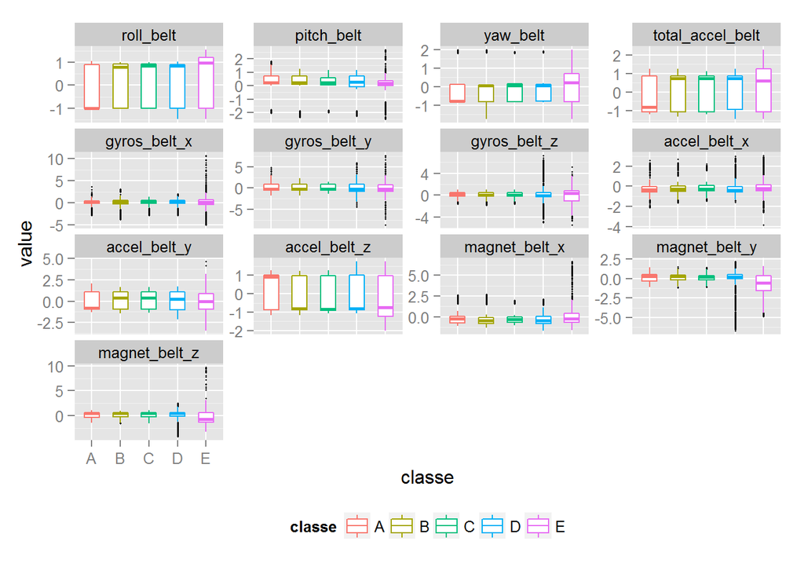

```r
beltMelt<-melt(belt,id.vars=c("classe"))
catPlot(beltMelt)
```

### Arm Measurements:

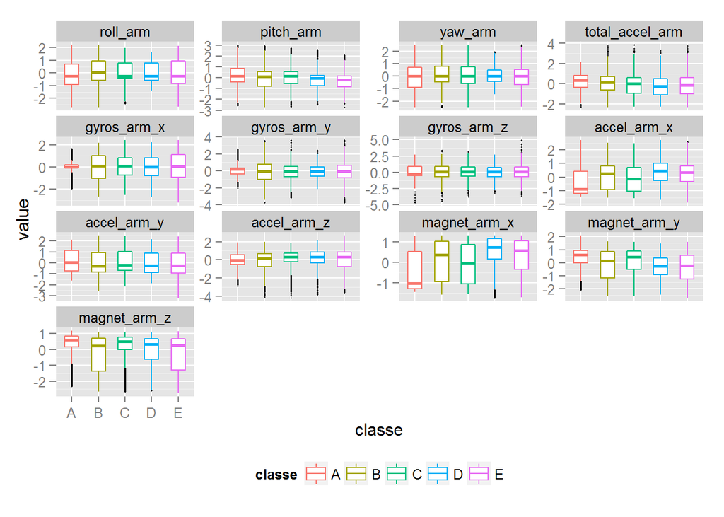

```r
armMelt<-(melt(arm,id.vars=c("classe")))
catPlot(armMelt)
```

### Forearm Measurements:

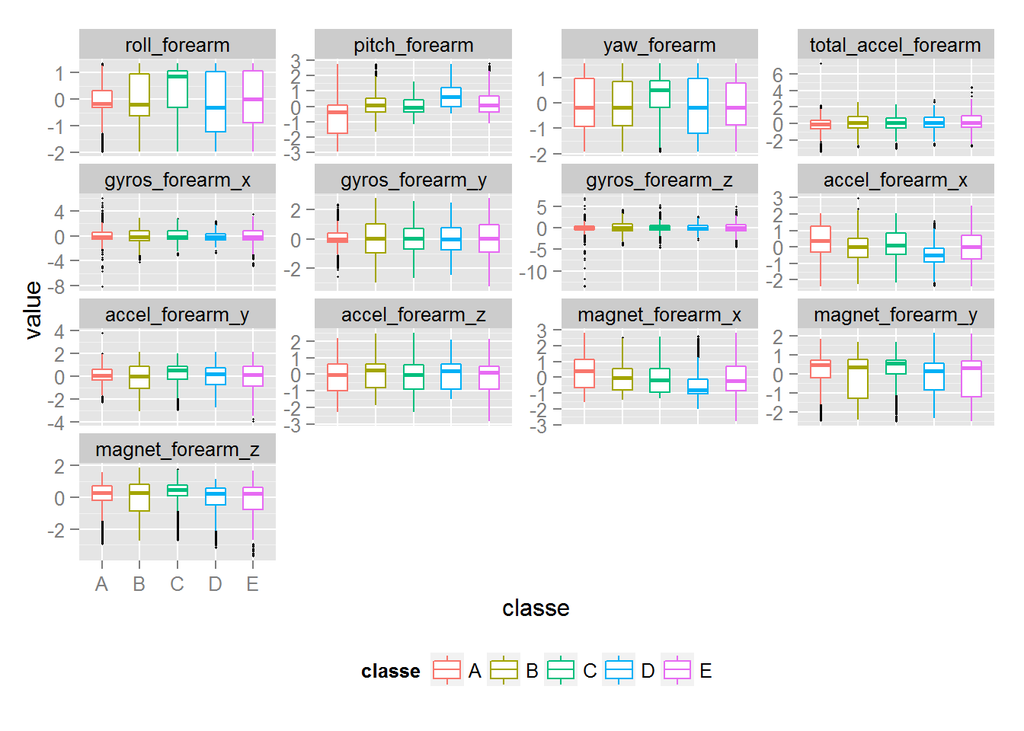

```r
forearmMelt<-melt(forearm,id.vars=c("classe"))
catPlot(forearmMelt)
```

### Dumbbell Measurements:

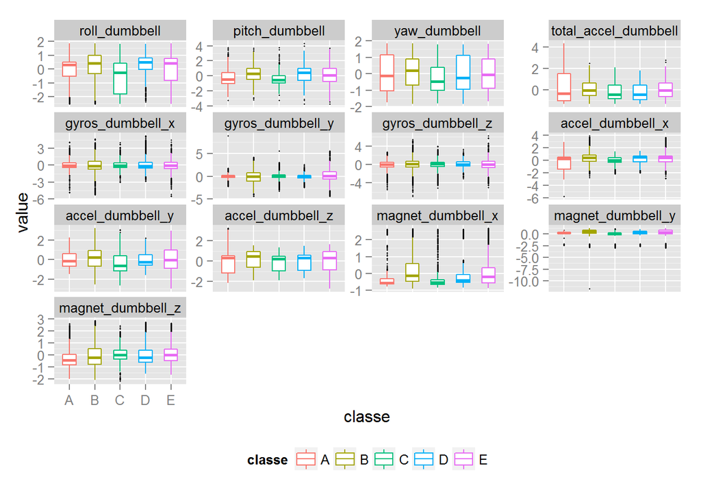

```r
dumbbellMelt<-melt(dumbbell,id.vars=c("classe"))
catPlot(dumbbellMelt)
```

## Model Development

Split the training data into two parts: one for model development and one for validation.

```r
set.seed(123)
split = createDataPartition(train$classe, p = 0.6, list=FALSE)

trM = train[split,]
trV= train[-split,]
```

Tune the mtry parameter for use in the random forest model. This parameter specifies how many variables are selected at each split point. This function starts at the default value and searches nearby for the optimal value (the one the produces the best Out-of-Bag error estimate).

```r
set.seed(111)
tuneRF(trM[,-53],trM[,53],ntreeTry=1000,stepFactor=1.5)
```

```
## mtry = 7  OOB error = 0.66%
## Searching left ...
## mtry = 5     OOB error = 0.69%
## -0.03846154 0.05
## Searching right ...
## mtry = 10    OOB error = 0.62%
## 0.06410256 0.05
## mtry = 15    OOB error = 0.66%
## -0.06849315 0.05
```

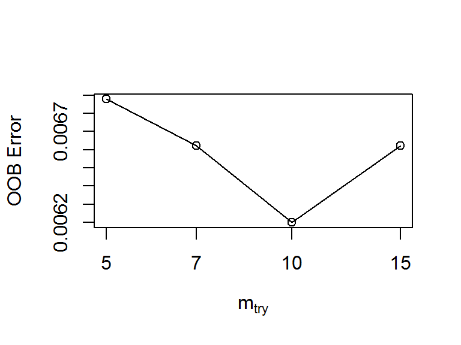

```
##        mtry    OOBError
## 5.OOB     5 0.006878397
## 7.OOB     7 0.006623641
## 10.OOB   10 0.006199049
## 15.OOB   15 0.006623641
```

Use mtry = 10 in Random Forest Model

```r
rf<-randomForest(classe~.,data=trM, ntree=1000,mtry=10,importance=TRUE)
```

Look at most important variables:

```r
imp<-importance(rf,scale=TRUE)
head(sort(imp[,6],decreasing=TRUE),12)
```

```
##          yaw_belt         roll_belt magnet_dumbbell_z        pitch_belt
##          89.98497          87.53850          77.10264          72.52968
## magnet_dumbbell_y     pitch_forearm       gyros_arm_y  accel_dumbbell_z
##          62.34915          59.92641          52.92081          48.97429
##  accel_dumbbell_y      roll_forearm      magnet_arm_z     magnet_belt_x
##          48.55970          46.77608          46.29337          46.00098
```

Look at model statistics and error plot:

```r
rf
```

```
##
## Call:
##  randomForest(formula = classe ~ ., data = trM, ntree = 1000,      mtry = 10, importance = TRUE)
##                Type of random forest: classification
##                      Number of trees: 1000
## No. of variables tried at each split: 10
##
##         OOB estimate of  error rate: 0.64%
## Confusion matrix:
##      A    B    C    D    E class.error
## A 3344    2    0    1    1 0.001194743
## B   12 2263    4    0    0 0.007020623
## C    0   17 2033    4    0 0.010223953
## D    1    0   24 1903    2 0.013989637
## E    0    0    2    5 2158 0.003233256
```

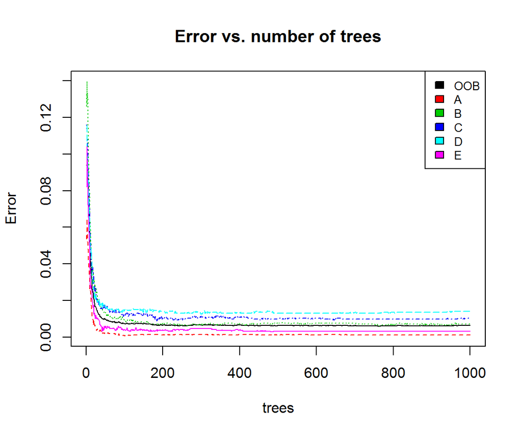

```r
plot(rf, main="Error vs. number of trees")
legend("topright", colnames(rf$err.rate),col=1:6,cex=0.8,fill=1:6)
```

The predicted OOB (out of sample) error is: 0.64% . The Random Forest algorithm performs the cross validation inherently but just for completeness let’s check that against the validation data. From the plot you can see that the error reduces with the number of trees. Class “A” seems to have the lowest error rate and class “D” the highest.

```r
rfPred<-predict(rf,newdata=trV)
cm<-confusionMatrix(rfPred,trV$classe)
print (cm)
```

```
## Confusion Matrix and Statistics
##
##           Reference
## Prediction    A    B    C    D    E
##          A 2230    8    0    0    0
##          B    2 1507   10    0    0
##          C    0    3 1353   13    3
##          D    0    0    5 1273    4
##          E    0    0    0    0 1435
##
## Overall Statistics
##
##                Accuracy : 0.9939
##                  95% CI : (0.9919, 0.9955)
##     No Information Rate : 0.2845
##     P-Value [Acc > NIR] : < 2.2e-16
##
##                   Kappa : 0.9923
##  Mcnemar's Test P-Value : NA
##
## Statistics by Class:
##
##                      Class: A Class: B Class: C Class: D Class: E
## Sensitivity            0.9991   0.9928   0.9890   0.9899   0.9951
## Specificity            0.9986   0.9981   0.9971   0.9986   1.0000
## Pos Pred Value         0.9964   0.9921   0.9862   0.9930   1.0000
## Neg Pred Value         0.9996   0.9983   0.9977   0.9980   0.9989
## Prevalence             0.2845   0.1935   0.1744   0.1639   0.1838
## Detection Rate         0.2842   0.1921   0.1724   0.1622   0.1829
## Detection Prevalence   0.2852   0.1936   0.1749   0.1634   0.1829
## Balanced Accuracy      0.9988   0.9954   0.9931   0.9943   0.9976
```

## Conclusion:

The model has an accuracy of 0.9938822, and an out of sample error rate of 0.6117767%, which is consistent with our expectations. Hopefully this accuracy will be sufficient to successfully predict the 20 cases in the test set!

### References:

Data: Velloso, E.; Bulling, A.; Gellersen, H.; Ugulino, W.; Fuks, H. Qualitative Activity Recognition of Weight Lifting Exercises. Proceedings of 4th International Conference in Cooperation with SIGCHI (Augmented Human ’13) . Stuttgart, Germany: ACM SIGCHI, 2013.

Read more: http://groupware.les.inf.puc-rio.br/har#sbia_paper_section#ixzz3aUa2ofBD